# Huisrijk Vergunningsdossier Tool

#### Uitvoeren van de code

Nu kunnen we alle eerder geschreven functies uitvoeren en het gewenste directory opgeven.

```python
raw_df = process_directory(dossierPath)
processed_df = process_dataframe(raw_df)
processed_df.sample(5)
```

|  | Creator | CreationDate | Filename | NonSpaceCharacterCount | PageCount | ModDate | Author | Producer | Title | Subject | ... | MSIP_Label_0ce80e9c-661b-453a-b52e-c00e4f65cc34_ContentBits | MSIP_Label_0ce80e9c-661b-453a-b52e-c00e4f65cc34_Enabled | MSIP_Label_0ce80e9c-661b-453a-b52e-c00e4f65cc34_Method | MSIP_Label_0ce80e9c-661b-453a-b52e-c00e4f65cc34_SiteId | Header | HeaderId | Template | TemplateId | Typist | LastSavedBy |
| --- | --- | --- | --- | --- | --- | --- | --- | --- | --- | --- | --- | --- | --- | --- | --- | --- | --- | --- | --- | --- | --- |
| 87 | MicroStation 8.11.9.919 by Bentley Systems, In... | 2021-04-13 07:15:30 | C:\Users\mjmbr\Downloads\Dossiers\Dossiers2\NL... | 384 | 1 | 2021-04-13 07:15:31 | <NA> | Adobe PDF Library 9.0 | Boomwaaarde Winkelsestraat17 | None | ... | NaN | NaN | NaN | NaN | NaN | NaN | NaN | NaN | NaN | NaN |
| 240 | Canon iR-ADV C5035 | 2012-07-05 11:31:42 | C:\Users\mjmbr\Downloads\Dossiers\Dossiers2\NL... | 1 | 1 | NaT | None | Adobe PSL 1.1e for Canon | None | None | ... | NaN | NaN | NaN | NaN | NaN | NaN | NaN | NaN | NaN | NaN |
| 187 | Microsoft® Word voor Microsoft 365 | 2021-12-14 10:05:31 | C:\Users\mjmbr\Downloads\Dossiers\Dossiers2\NL... | 5838 | 4 | 2021-12-14 10:05:31 | Fons Peeters | Microsoft® Word voor Microsoft 365 | None | None | ... | NaN | NaN | NaN | NaN | NaN | NaN | NaN | NaN | NaN | NaN |
| 145 | MicroStation 8.11.9.919 by Bentley Systems, In... | 2022-08-02 08:16:02 | C:\Users\mjmbr\Downloads\Dossiers\Dossiers2\NL... | 3255 | 1 | 2022-10-17 13:34:17 | <NA> | Adobe PDF Library 9.0 | NL.IMRO.0855.BSP2022008-a001-Boomwaardekaart | None | ... | NaN | NaN | NaN | NaN | NaN | NaN | NaN | NaN | NaN | NaN |
| 89 | Microsoft® Word voor Office 365 | 2019-10-04 12:48:30 | C:\Users\mjmbr\Downloads\Dossiers\Dossiers2\NL... | 9305 | 4 | 2019-10-04 12:48:30 | John van Uden | Microsoft® Word voor Office 365 | Aan het College van Burgemeester en Wethouders | None | ... | NaN | NaN | NaN | NaN | NaN | NaN | NaN | NaN | NaN | NaN |

5 rows × 26 columns

#### Aanmaken en opslaan CSV

Nu we de gewenste informatie uit de PDF's hebben gehaald kunnen we de dataframe omzetten en opslaan als CSV.

```python
processed_df.to_csv(datasetPath + "/pdf_metadata.csv", index=False)
print(f"DataFrame saved as pdf_metadata.")
```

```
DataFrame saved as pdf_metadata.
```

### PDF metadata schoonmaken

In dit onderdeel wordt de dataset bekeken die uit de PDF's is gehaald en maken wordt deze schoon gemaakt om het overzichtelijk te maken

#### De Dataset bekijken

Laten we voordat we iets veranderen een willekeurige sample van de dataset bekijken. Het is beelangrijk om te onthouden dat deze code er vanuit gaat dat het CVS bestand in dezelfde omgeving staat als dit notebook

in de codecell achter "df.sample(x) kan je de X veranderen naar het gewenste getal om de grootte van de sample te bepalen. Ik raad wel aan het getal 60 of lager te houden, dan word elke rij nog getoont. Een hoger getal resulteert in een sample waar enkele rijen getoont worden en de rest getoont word als stippel lijn.

```python
csv_filename = "/pdf_metadata.csv"
df = pd.read_csv(datasetPath + csv_filename)
df.sample(5)
```

|  | Creator | CreationDate | Filename | NonSpaceCharacterCount | PageCount | ModDate | Author | Producer | Title | Subject | ... | MSIP_Label_0ce80e9c-661b-453a-b52e-c00e4f65cc34_ContentBits | MSIP_Label_0ce80e9c-661b-453a-b52e-c00e4f65cc34_Enabled | MSIP_Label_0ce80e9c-661b-453a-b52e-c00e4f65cc34_Method | MSIP_Label_0ce80e9c-661b-453a-b52e-c00e4f65cc34_SiteId | Header | HeaderId | Template | TemplateId | Typist | LastSavedBy |
| --- | --- | --- | --- | --- | --- | --- | --- | --- | --- | --- | --- | --- | --- | --- | --- | --- | --- | --- | --- | --- | --- |
| 0 | Esri ArcMap 10.5.0.6491 | 2021-12-21 10:17:01 | C:\Users\mjmbr\Downloads\Dossiers\Dossiers2\NL... | 982 | 1 | NaN | NaN | NaN | NaN | NaN | ... | NaN | NaN | NaN | NaN | NaN | NaN | NaN | NaN | NaN | NaN |
| 163 | Scan and Fax Manager | 2023-03-02 08:45:35 | C:\Users\mjmbr\Downloads\Dossiers\Dossiers2\NL... | 1948 | 1 | 2023-03-02 08:45:35 | NaN | ABBYY FineReader Engine 11 | NaN | NaN | ... | NaN | NaN | NaN | NaN | NaN | NaN | NaN | NaN | NaN | NaN |
| 237 | PDFCreator Version 1.7.2 | 2014-04-09 11:54:35 | C:\Users\mjmbr\Downloads\Dossiers\Dossiers2\NL... | 6594 | 3 | 2014-04-09 11:54:35 | RuGe | GPL Ghostscript 9.10; modified using iTextShar... | NaN | NaN | ... | NaN | NaN | NaN | NaN | NaN | NaN | NaN | NaN | NaN | NaN |
| 235 | Microsoft® Word 2010 | 2015-06-12 14:46:20 | C:\Users\mjmbr\Downloads\Dossiers\Dossiers2\NL... | 9594 | 4 | 2015-06-12 14:46:20 | josa | Microsoft® Word 2010 | NaN | NaN | ... | NaN | NaN | NaN | NaN | NaN | NaN | NaN | NaN | NaN | NaN |
| 77 | Microsoft® Word voor Microsoft 365 | 2022-03-10 11:35:39 | C:\Users\mjmbr\Downloads\Dossiers\Dossiers2\NL... | 7198 | 7 | 2022-03-10 11:35:39 | Glerum, Peter | Microsoft® Word voor Microsoft 365 | NaN | NaN | ... | NaN | NaN | NaN | NaN | NaN | NaN | NaN | NaN | NaN | NaN |

5 rows × 26 columns

#### Het aantal datapunten per kolom tonen

Zoals te zien is in de sample hebben we een hele hoop Nan (not a number) in de dataset staan. dit zijn lege cellen zonder data. Het kan nu interessante inzicht geven om de hoeveelheid rijen die wel data bevatten per kolom te vertonen

```python
pd.set_option('display.max_rows', None)

# Calculate the number of NaN values in each column of the DataFrame
nonnan_counts = df.count()
print(nonnan_counts)
```

```
Creator                                                        222
CreationDate                                                   239
Filename                                                       242
NonSpaceCharacterCount                                         242
PageCount                                                      242
ModDate                                                        216
Author                                                         148
Producer                                                       225
Title                                                          107
Subject                                                          0
Keywords                                                         0
Company                                                         12
SourceModified                                                   2
calculation[0]                                                   4
validationKey                                                    4
CreatorTool                                                      5
MSIP_Label_0ce80e9c-661b-453a-b52e-c00e4f65cc34_ContentBits      2
MSIP_Label_0ce80e9c-661b-453a-b52e-c00e4f65cc34_Enabled          2
MSIP_Label_0ce80e9c-661b-453a-b52e-c00e4f65cc34_Method           2
MSIP_Label_0ce80e9c-661b-453a-b52e-c00e4f65cc34_SiteId           2
Header                                                           1
HeaderId                                                         1
Template                                                         1
TemplateId                                                       1
Typist                                                           1
LastSavedBy                                                      1
dtype: int64
```

#### De bijna legen kolommen laten vallen

De threshold zet een grenswaarde van hoeveelheid rijen data die een kolom moet hebben om bewaard te blijven. **Deze kan naar wens aangepast worden**

```python
threshold = 1
```

```python
df_dropped = df.dropna(axis=1, thresh=threshold)
df_dropped.sample(5)
```

|  | Creator | CreationDate | Filename | NonSpaceCharacterCount | PageCount | ModDate | Author | Producer | Title | Company | ... | MSIP_Label_0ce80e9c-661b-453a-b52e-c00e4f65cc34_ContentBits | MSIP_Label_0ce80e9c-661b-453a-b52e-c00e4f65cc34_Enabled | MSIP_Label_0ce80e9c-661b-453a-b52e-c00e4f65cc34_Method | MSIP_Label_0ce80e9c-661b-453a-b52e-c00e4f65cc34_SiteId | Header | HeaderId | Template | TemplateId | Typist | LastSavedBy |
| --- | --- | --- | --- | --- | --- | --- | --- | --- | --- | --- | --- | --- | --- | --- | --- | --- | --- | --- | --- | --- | --- |
| 107 | MicroStation 8.11.9.919 by Bentley Systems, In... | 2022-02-22 07:28:06 | C:\Users\mjmbr\Downloads\Dossiers\Dossiers2\NL... | 585 | 1 | 2022-02-22 07:28:07 | NaN | Adobe PDF Library 9.0 | NL.IMRO.0855.BSP2021025-a001-Boomwaardekaart | NaN | ... | NaN | NaN | NaN | NaN | NaN | NaN | NaN | NaN | NaN | NaN |
| 180 | PScript5.dll Version 5.2.2 | 2023-04-14 10:42:29 | C:\Users\mjmbr\Downloads\Dossiers\Dossiers2\NL... | 6511 | 4 | 2023-06-09 14:47:08 | fokkingac | Acrobat Distiller 23.0 (Windows) | Koningsoord 2023 - 23-04-14 - 03 - plankostens... | NaN | ... | NaN | NaN | NaN | NaN | NaN | NaN | NaN | NaN | NaN | NaN |
| 63 | PScript5.dll Version 5.2.2 | 2021-07-01 16:45:38 | C:\Users\mjmbr\Downloads\Dossiers\Dossiers2\NL... | 79996 | 73 | 2021-11-05 10:36:09 | louise.veenman | Acrobat Distiller 21.0 (Windows) | Microsoft Word - 07791-54795-02 (Rapport) | NaN | ... | NaN | NaN | NaN | NaN | NaN | NaN | NaN | NaN | NaN | NaN |
| 176 | PScript5.dll Version 5.2.2 | 2023-01-18 09:34:44 | C:\Users\mjmbr\Downloads\Dossiers\Dossiers2\NL... | 6314 | 3 | 2023-06-09 14:47:41 | fokkingac | Acrobat Distiller 22.0 (Windows) | Microsoft Word - 230105_Position_paper_paramet... | NaN | ... | NaN | NaN | NaN | NaN | NaN | NaN | NaN | NaN | NaN | NaN |
| 90 | KM_C224e | 2021-06-25 08:17:21 | C:\Users\mjmbr\Downloads\Dossiers\Dossiers2\NL... | 3 | 3 | 2021-06-25 09:16:02 | NaN | KONICA MINOLTA bizhub C224e | KM_C224e-20210625081721 | NaN | ... | NaN | NaN | NaN | NaN | NaN | NaN | NaN | NaN | NaN | NaN |

5 rows × 24 columns

#### Extra kolommen droppen

```python
columns_to_drop = ['validationKey', 'SourceModified','calculation[0]']
df_dropped = df_dropped.drop(columns=columns_to_drop)

df_dropped.sample(5)
```

|  | Creator | CreationDate | Filename | NonSpaceCharacterCount | PageCount | ModDate | Author | Producer | Title | Company | ... | MSIP_Label_0ce80e9c-661b-453a-b52e-c00e4f65cc34_ContentBits | MSIP_Label_0ce80e9c-661b-453a-b52e-c00e4f65cc34_Enabled | MSIP_Label_0ce80e9c-661b-453a-b52e-c00e4f65cc34_Method | MSIP_Label_0ce80e9c-661b-453a-b52e-c00e4f65cc34_SiteId | Header | HeaderId | Template | TemplateId | Typist | LastSavedBy |
| --- | --- | --- | --- | --- | --- | --- | --- | --- | --- | --- | --- | --- | --- | --- | --- | --- | --- | --- | --- | --- | --- |
| 80 | Microsoft® Word 2019 | 2021-11-26 16:14:35 | C:\Users\mjmbr\Downloads\Dossiers\Dossiers2\NL... | 19030 | 6 | 2021-12-13 13:44:47 | Wissing | Microsoft® Word 2019 | NaN | NaN | ... | NaN | NaN | NaN | NaN | NaN | NaN | NaN | NaN | NaN | NaN |
| 135 | Microsoft® Excel® voor Microsoft 365 | 2022-12-05 15:42:36 | C:\Users\mjmbr\Downloads\Dossiers\Dossiers2\NL... | 3692 | 1 | 2022-12-05 15:42:36 | Thijs Kieboom | Microsoft® Excel® voor Microsoft 365 | NaN | NaN | ... | NaN | NaN | NaN | NaN | NaN | NaN | NaN | NaN | NaN | NaN |
| 33 | PDFCreator 3.3.0.2468 | 2021-02-05 10:09:37 | C:\Users\mjmbr\Downloads\Dossiers\Dossiers2\NL... | 7332 | 7 | 2021-02-05 10:09:37 | Bianca | PDFCreator 3.3.0.2468 | 07258-006_Notitie invoergegevens AERIUS_Aanleg... | NaN | ... | NaN | NaN | NaN | NaN | NaN | NaN | NaN | NaN | NaN | NaN |
| 105 | Power PDF Create | 2022-04-25 10:18:48 | C:\Users\mjmbr\Downloads\Dossiers\Dossiers2\NL... | 12080 | 5 | 2022-04-25 10:18:52 | Glerum, Peter | Power PDF Create | 20220405 ontwerpbesluit Woontoren Spoorpark | Gemeente Tilburg | ... | NaN | NaN | NaN | NaN | NaN | NaN | NaN | NaN | NaN | NaN |
| 57 | www.2pdf.nl | 2020-09-23 09:20:15 | C:\Users\mjmbr\Downloads\Dossiers\Dossiers2\NL... | 6761 | 4 | 2020-09-23 09:20:15 | NaN | www.2pdf.nl | NaN | NaN | ... | NaN | NaN | NaN | NaN | NaN | NaN | NaN | NaN | NaN | NaN |

5 rows × 21 columns

```python
replacementString = dossierPath.replace('\\','/')
df_dropped['Filename'] = df_dropped['Filename'].str.replace(replacementString, '', regex=False)
df_dropped.sample(5)
```

|  | Creator | CreationDate | Filename | NonSpaceCharacterCount | PageCount | ModDate | Author | Producer | Title | Company | ... | MSIP_Label_0ce80e9c-661b-453a-b52e-c00e4f65cc34_ContentBits | MSIP_Label_0ce80e9c-661b-453a-b52e-c00e4f65cc34_Enabled | MSIP_Label_0ce80e9c-661b-453a-b52e-c00e4f65cc34_Method | MSIP_Label_0ce80e9c-661b-453a-b52e-c00e4f65cc34_SiteId | Header | HeaderId | Template | TemplateId | Typist | LastSavedBy |
| --- | --- | --- | --- | --- | --- | --- | --- | --- | --- | --- | --- | --- | --- | --- | --- | --- | --- | --- | --- | --- | --- |
| 200 | Microsoft® Excel® 2019 | 2022-01-18 14:41:13 | C:\Users\mjmbr\Downloads\Dossiers\Dossiers2\NL... | 1518 | 1 | 2022-01-31 13:24:07 | DRplusArchitecten | Microsoft® Excel® 2019 | NaN | NaN | ... | NaN | NaN | NaN | NaN | NaN | NaN | NaN | NaN | NaN | NaN |
| 186 | Microsoft® Word voor Microsoft 365 | 2021-08-11 09:41:41 | C:\Users\mjmbr\Downloads\Dossiers\Dossiers2\NL... | 11941 | 9 | 2021-08-11 10:14:37 | punueji | Microsoft® Word voor Microsoft 365 | NaN | NaN | ... | NaN | NaN | NaN | NaN | NaN | NaN | NaN | NaN | NaN | NaN |
| 167 | MicroStation 8.11.9.919 by Bentley Systems, In... | 2023-02-21 11:01:52 | C:\Users\mjmbr\Downloads\Dossiers\Dossiers2\NL... | 364 | 1 | 2023-02-21 11:01:53 | NaN | Adobe PDF Library 9.0 | NL.IMRO.0855.BSP2023003-a001-Luchtvaartverkeer... | NaN | ... | NaN | NaN | NaN | NaN | NaN | NaN | NaN | NaN | NaN | NaN |
| 114 | Microsoft® Word voor Microsoft 365 | 2021-10-19 16:56:57 | C:\Users\mjmbr\Downloads\Dossiers\Dossiers2\NL... | 11209 | 12 | 2021-10-19 14:58:59 | F. Gevers | 3-Heights(TM) PDF Security Shell 4.8.25.2 (htt... | Stikstofdepositieberekening Woontoren Spoorpar... | NaN | ... | NaN | NaN | NaN | NaN | NaN | NaN | NaN | NaN | NaN | NaN |
| 21 | Microsoft® Word voor Microsoft 365 | 2023-04-17 09:46:39 | C:\Users\mjmbr\Downloads\Dossiers\Dossiers2\NL... | 74065 | 34 | 2023-04-17 09:46:39 | Peelen Ties, T.J. | Microsoft® Word voor Microsoft 365 | TOE01-0474052-01B_Toelichting.docx | NaN | ... | NaN | NaN | NaN | NaN | NaN | NaN | NaN | NaN | NaN | NaN |

5 rows × 21 columns

#### De nieuwe Dataset opslaan

Als onze dataset naar wensen is schoongemaakt moet deze wel opgeslagen worden in een nieuw bestand.

```python
new_csv_filename = "/cleaned_pdf_metadata.csv"
df_dropped.to_csv(datasetPath + new_csv_filename, index=False)

print(f"Modified DataFrame saved as '{new_csv_filename}'.")
```

```
Modified DataFrame saved as '/cleaned_pdf_metadata.csv'.
```

### Kenmerkende woorden

Met toepassing van TF-IDF (Term Frequency Inverse Document Frequency) kan er een graad van belang worden gekoppeld aan worden in de tekstdocumenten van de dossiers. Voor het IDF onderdeel is het belangrijk dat er een collectie van documenten wordt meegegeven.

```python
from bs4 import BeautifulSoup
import re
!pip install unidecode
import unidecode
!pip install PyPDF2
import PyPDF2
from sklearn.feature_extraction.text import TfidfVectorizer
import pandas as pd
```

Om enkel de tekst van de documenten te behouden worden de tekens en en getallen er uit gehaald.

```python
def RemoveSpecialCharacters(text):
  #remove identifiers
  text = re.sub(r'[\(\[\]\%\.\,\-\–\¼\½\¾\"\'\’\/\:\;\*\?\[\)\]]', '', text)
  # Use a regular expression to add a space before each capital letter
  text = re.sub(r'(?<=[a-z])(?=[A-Z])', ' ', text)
  # Remove all numbers
  text = re.sub(r'\d+', '', text)
  # Transform & to the word and
  text = re.sub(r'[\&\\]', 'en', text)
  #remove accents
  text = unidecode.unidecode(text)
  # Remove spacing
  text = re.sub(r'\s+', ' ', text)
  return text
```

Met de onderstaande methode worden de waarden bepaald voor de belangrijkste woorden.

```python
def TFIDFFeatures(TrainData, Vectorizer):
    # Train het model met de train data
    TrainMatrix = Vectorizer.fit_transform(TrainData)

    # Haal de features op voor kolom namen
    featureNames = Vectorizer.get_feature_names_out()

    # Converteer matrix naar array
    TFIDFArray = TrainMatrix.toarray()

    # visualiseer in dataframe
    dfTFIDF = pd.DataFrame(TFIDFArray, columns=featureNames)

    return dfTFIDF
```

Aangezien veel voorkomende woorden een hogere waarde krijgen, kan het zijn dat stopwoorden hoog zullen scoren. Echter zijn deze niet kenmerkend voor de documenten. Uit de volgende bron is een collectie van Nederlandse stopwoorden gehaald:  
https://help.carerix.com/nl/articles/2074382-stopwoorden

```python
stopwoorden = ['aan', 'af', 'al', 'alle', 'alleen', 'alles', 'als', 'alsmede', 'ander', 'andere', 'anders',
'ben', 'bij', 'bijna', 'bijv', 'bijvoorbeeld', 'binnen', 'boven', 'bovendien', 'bv',
'daar', 'daaraan', 'daarbij', 'daarbuiten', 'daardoor', 'daarin', 'daarna', 'daarnaast', 'daarom', 'daaronder', 'daarop', 'daarover', 'daartoe', 'daaruit', 'daarvan', 'daarvoor',
'dan', 'dat', 'de', 'der', 'deze', 'die', 'dit', 'door', 'doordat', 'dus', 'dwz','echter', 'een', 'eens', 'eerst', 'en', 'enz', 'er', 'ermee', 'erg', 'ergens', 'ervan', 'ervaring', 'ervoor', 'etc', 'even', 'evenals', 'eveneens',
'ge', 'geen', 'gehad', 'geweest', 'geworden','had', 'hadden', 'heb', 'hebben', 'hebt', 'heden', 'heeft', 'hem', 'hen', 'het',
'hier', 'hieraan', 'hierbij', 'hierdoor', 'hierin', 'hiermee', 'hierna', 'hieronder', 'hierop', 'hiertoe', 'hieruit', 'hiervan', 'hiervoor','hij', 'hoe', 'hoewel', 'hun',
'ik', 'in', 'indien', 'is','ja', 'je', 'jij', 'jullie','kan', 'kon', 'konden', 'kunt', 'kunnen','maar', 'maw', 'me', 'mee', 'men', 'met', 'middels', 'mijn', 'misschien', 'mits',
'na', 'naar', 'naast', 'nadat', 'nee', 'net', 'niet', 'niets', 'nl', 'nog', 'nogal', 'nou', 'nu',
'of', 'om', 'omdat', 'ondermeer', 'ons', 'onze', 'ook', 'op', 'over', 'overig', 'overige', 'overigens','reeds','sinds', 'slechts', 'soms',
'tbv', 'te', 'tegen', 'ten', 'tenzij', 'ter', 'terug', 'terwijl', 'tevens', 'tijdens', 'toch', 'toe', 'toen', 'tot', 'totdat', 'tussen',
'uit', 'uw', 'vaak', 'van', 'vanaf', 'vandaar', 'vanuit', 'vanwege', 'vervolgens', 'volgens', 'voor', 'vooraf', 'vooral', 'voordat', 'voorheen', 'voornamelijk','waar', 'waaraan', 'waarbij', 'waardoor', 'waarin', 'waarmee', 'waarna', 'waarom', 'waarop', 'waaronder', 'waaruit', 'waarvan', 'waarvoor', 'wanneer', 'want', 'waren', 'was', 'wat', 'we', 'weer', 'wel', 'welk', 'welke', 'wellicht', 'werd', 'werden', 'wie', 'wij', 'worden', 'wordt',
'zal', 'ze', 'zeer', 'zelf', 'zelfs', 'zich', 'zij', 'zijn', 'zo', 'zoals', 'zodat', 'zonder', 'zowel', 'zou', 'zouden', 'zult', 'zullen']
```

#### HTML uitlezen

Aan de hand van BeautifulSoup wordt de tekst uit de HTML bestanden gehaald

```python
def GetDocumentTextHTML(fileLocation):
  with open(fileLocation, encoding="utf8") as file:
    soup = BeautifulSoup(file, 'html.parser')
    for tag in soup(['script', 'style']):
        tag.decompose()
    return soup.get_text()
```

#### PDF uitlezen

Aan de hand van PyPDF2 wordt de tekst uit de PDF bestanden gehaald

```python
def GetDocumentTextPDF(fileLocation):
  with open(fileLocation, 'rb') as file:
    reader = PyPDF2.PdfReader(file)
    text = ''
    for page in reader.pages:
        text += page.extract_text()
  return text
```

#### Kenmerkende woorden bepalen

Er wordt een dataframe gemaakt waarin verschillende documenten gekoppeld worden aan het type document dat ze zijn. In dit voorbeeld zijn dat drie bestemmingsplannen, drie omgevingvergunningen en drie wijzigingsplannen.

```python
Documenten = [['Bestemmingsplan',1],['Bestemmingsplan',2],['Bestemmingsplan',3],['Omgevingvergunning',4],['Omgevingvergunning',5],['Omgevingvergunning',6],['Wijzigingsplan',7],['Wijzigingsplan',8],['Wijzigingsplan',9]]

BestemmingsplanDocText = GetDocumentTextHTML(dossierPath + '/NL-IMRO-1724-BPBlnt1115-ONTW-2023-08-11-00-40-00/r_NL.IMRO.1724.BPBlnt1115-ONTW.html')
Documenten[0][1] = RemoveSpecialCharacters(BestemmingsplanDocText)
BestemmingsplanDocText = GetDocumentTextHTML(dossierPath + r'/NL-IMRO-1728-BPA5020KomHap2021-VAST-2023-07-31-12-42-00/r_NL.IMRO.1728.BPA5020KomHap2021-VAST.html')
Documenten[1][1] = RemoveSpecialCharacters(BestemmingsplanDocText)
BestemmingsplanDocText = GetDocumentTextHTML(dossierPath + r'/NL-IMRO-1734-0366BUITHningvld6a-ONT1-2023-06-16-15-22-00/r_NL.IMRO.1734.0366BUITHningvld6a-ONT1.html')
Documenten[2][1] = RemoveSpecialCharacters(BestemmingsplanDocText)

OmgevingsDocText = GetDocumentTextPDF(dossierPath + r'/NL-IMRO-0502-OAB22FascBlvrd2K4-4001-2023-08-16-12-14-00/d_NL.IMRO.0502.OAB22FascBlvrd2K4-4001.pdf')
Documenten[3][1] = RemoveSpecialCharacters(OmgevingsDocText)
OmgevingsDocText = GetDocumentTextPDF(dossierPath + r'/NL-IMRO-1708-BRStgoor5OV-ON01-2023-08-15-00-47-00/t_NL.IMRO.1708.BRStgoor5OV-ON01.pdf')
Documenten[4][1] = RemoveSpecialCharacters(OmgevingsDocText)
OmgevingsDocText = GetDocumentTextPDF(dossierPath + r'/NL-IMRO-1876-OV00052-ON01-2023-06-16-00-11-00/b_NL.IMRO.1876.OV00052-ON01_8.pdf')
Documenten[5][1] = RemoveSpecialCharacters(OmgevingsDocText)

WijzigingDocText = GetDocumentTextHTML(dossierPath + r'/NL-IMRO-0441-WP2LGHTRAMBAAN13-ON01-2023-07-13-12-31-00/r_NL.IMRO.0441.WP2LGHTRAMBAAN13-ON01.html')
Documenten[6][1] = RemoveSpecialCharacters(WijzigingDocText)
WijzigingDocText = GetDocumentTextHTML(dossierPath + r'/NL-IMRO-1740-wpOClavierenstr3-ont1-2023-07-20-00-32-00/t_NL.IMRO.1740.wpOClavierenstr3-ont1.html')
Documenten[7][1] = RemoveSpecialCharacters(WijzigingDocText)
WijzigingDocText = GetDocumentTextHTML(dossierPath + r'/NL-IMRO-1783-abp00000013w174-ON01-2023-07-21-00-37-00/t_NL.IMRO.1783.abp00000013w174-ON01.html')
Documenten[8][1] = RemoveSpecialCharacters(WijzigingDocText)

dataframe = pd.DataFrame(Documenten, columns=['Type', 'Text'])
```

Nu de dataset is gemaakt kunnen de bestemmingsplannen gesplits worden en kan op basis van de 'Text' kolom de TF IDF waarden bepaald worden. Om een beter beeld te vormen wat werkelijk de belangrijke waarde zijn, wordt er een grenswaarde van 0.4 aan gegeven.

```python
dataframeBestemming = dataframe[dataframe['Type'] == 'Bestemmingsplan']

Vectorizer = TfidfVectorizer(analyzer='word' , stop_words=stopwoorden)

dfBestemmingFeatures = TFIDFFeatures(dataframeBestemming['Text'], Vectorizer)

dfBestemmingFeaturesImportant = dfBestemmingFeatures.copy()

# Selecteer alle kolommen met een waarde van 0
columns_to_remove = dfBestemmingFeaturesImportant.columns[dfBestemmingFeaturesImportant.sum() < 0.4]

# Verwijder de geselecteerde kolommen
dfBestemmingFeaturesImportant = dfBestemmingFeaturesImportant.drop(columns=columns_to_remove)
dfBestemmingFeaturesImportant.head()
```

|  | archeologische | artikel | bouwwerken | enof | gebruik | gronden | max | omgevingsvergunning | zijnde |
| --- | --- | --- | --- | --- | --- | --- | --- | --- | --- |
| 0 | 0.000000 | 0.167462 | 0.256775 | 0.150716 | 0.173044 | 0.161880 | 0.415856 | 0.117223 | 0.133970 |
| 1 | 0.228715 | 0.121372 | 0.222022 | 0.085848 | 0.066606 | 0.165776 | 0.000000 | 0.227942 | 0.139134 |
| 2 | 0.296754 | 0.256546 | 0.191322 | 0.165233 | 0.160885 | 0.195670 | 0.000000 | 0.186974 | 0.152188 |

Vervolgens wordt hetzelfde gedaan voor omgevingvegunningen en wijzigingsplannen

```python
dataframeOmgeving = dataframe[dataframe['Type'] == 'Omgevingvergunning']

Vectorizer = TfidfVectorizer(analyzer='word' , stop_words=stopwoorden)

dfOmgevingFeatures = TFIDFFeatures(dataframeOmgeving['Text'], Vectorizer)

dfOmgevingFeaturesImportant = dfOmgevingFeatures.copy()

# Selecteer alle kolommen met een waarde van 0
columns_to_remove = dfOmgevingFeaturesImportant.columns[dfOmgevingFeaturesImportant.sum() < 0.2]

# Verwijder de geselecteerde kolommen
dfOmgevingFeaturesImportant = dfOmgevingFeaturesImportant.drop(columns=columns_to_remove)
dfOmgevingFeaturesImportant.head()
```

|  | bedenkingen | besluit | bijgebouw | fascinatio | onderbouwing | ontwerp | plan | plangebied | project | ruimtelijke | tenne | verklaring | watertoets | zienswijzen |
| --- | --- | --- | --- | --- | --- | --- | --- | --- | --- | --- | --- | --- | --- | --- |
| 0 | 0.257747 | 0.111635 | 0.000000 | 0.309297 | 0.065341 | 0.143751 | 0.131932 | 0.000000 | 0.013068 | 0.050743 | 0.000000 | 0.274931 | 0.000000 | 0.222160 |
| 1 | 0.000000 | 0.097930 | 0.243187 | 0.000000 | 0.168136 | 0.000000 | 0.026115 | 0.000000 | 0.311052 | 0.176273 | 0.000000 | 0.000000 | 0.016814 | 0.008407 |
| 2 | 0.000000 | 0.008717 | 0.000000 | 0.000000 | 0.000000 | 0.067348 | 0.043585 | 0.398498 | 0.000000 | 0.026151 | 0.206628 | 0.000000 | 0.235719 | 0.000000 |

```python
dataframeWijziging = dataframe[dataframe['Type'] == 'Wijzigingsplan']

Vectorizer = TfidfVectorizer(analyzer='word' , stop_words=stopwoorden)

dfWijzigingFeatures = TFIDFFeatures(dataframeWijziging['Text'], Vectorizer)

dfWijzigingFeaturesImportant = dfWijzigingFeatures.copy()

# Selecteer alle kolommen met een waarde van 0
columns_to_remove = dfWijzigingFeaturesImportant.columns[dfWijzigingFeaturesImportant.sum() < 0.22]

# Verwijder de geselecteerde kolommen
dfWijzigingFeaturesImportant = dfWijzigingFeaturesImportant.drop(columns=columns_to_remove)
dfWijzigingFeaturesImportant.head()
```

|  | bedragen | gebruik | gronden | meer | moet | onder | plan | plangebied | regels | ruimte | ruimtelijke | sub | westland |
| --- | --- | --- | --- | --- | --- | --- | --- | --- | --- | --- | --- | --- | --- |
| 0 | 0.243484 | 0.209172 | 0.126375 | 0.209172 | 0.013073 | 0.152521 | 0.117659 | 0.004358 | 0.135090 | 0.017431 | 0.004358 | 0.250863 | 0.000000 |
| 1 | 0.000000 | 0.022928 | 0.073368 | 0.041270 | 0.096296 | 0.114638 | 0.096296 | 0.155907 | 0.155907 | 0.110052 | 0.197177 | 0.000000 | 0.000000 |
| 2 | 0.000000 | 0.048230 | 0.055650 | 0.077911 | 0.111301 | 0.103881 | 0.051940 | 0.089041 | 0.063071 | 0.129851 | 0.215182 | 0.000000 | 0.301518 |

### Wordcloud

Vervolgens kan er aan de hand van de bovenstaande kenmerkende woorden wordclouds gemaakt worden om ze te visualiseren

```python
from wordcloud import WordCloud
from matplotlib import pyplot as plt
%matplotlib inline
import numpy as np
```

```python
def CreateWordCloud(dataframe, amount, title):
    # Totaal van elke kolom
    columnSums = dataframe.sum()
    # Sorteer de kolommen
    sortedColumns = columnSums.sort_values(ascending=False)
    # Selecteer bovenste * kolommen
    words = sortedColumns.head(amount)


    # Create a WordCloud object
    wordcloud = WordCloud(width=800, height=400, background_color='white')
    wordcloud.generate_from_frequencies(words)

    # Display the generated image:
    plt.imshow(wordcloud, interpolation='bilinear')
    plt.title(title)
    plt.axis("off")
    plt.show()
```

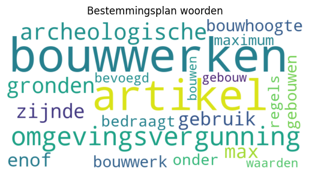

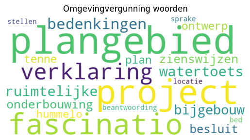

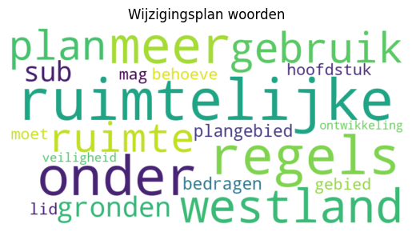

```python
CreateWordCloud(dfBestemmingFeatures,20, 'Bestemmingsplan woorden')
CreateWordCloud(dfOmgevingFeatures,20, 'Omgevingvergunning woorden')
CreateWordCloud(dfWijzigingFeatures,20, 'Wijzigingsplan woorden')
```

## NER

In het onderdeel wordt er gekeken naar NER, Named Entitiy Recognition. Het is een methode die valt onder natural language processing die het mogelijk maakt om woorden op basis van context te markeren en uit de tekst te halen.  
Barney, N. (2023, 10 maart). Named Entity Recognition (NER). WhatIs.  
https://www.techtarget.com/whatis/definition/named-entity-recognition-NER

In het kader van de wensen van Huisrijk kan een toepassing hiervan zijn om op basis van NER genoemde locaties uit de document teksten te kunnen halen. Een NER model kan getraind worden op de volgende teksten:

- "Ik woon in Tilburg"
- "Het gebouw staat in Breda"
- "In Rotterdam zijn veel boten"  
  Hierbij zal het vervolgens mogelijk moeten zijn om het woord "Amsterdam" als locatie te markeren in de volgende tekst: "Er wonen veel mensen in Amsterdam".  
  In de volgende stappen is onderzoek gedaan of er een NER model gemaakt kan worden die deze wens kan vervullen.

In de onderstaande codecel staat de eerste iteratie van het NER model, NER staat voor named entity recognition. Deze eerste iteratie geeft maar 1 woord een label, in dit geval heeft het NER model het woord Python het label PERSON gegeven. Aan deze eerste iteratie zijn nog geen extra labels en entiteiten toegevoegd.

```python
!pip install spacy
!python -m spacy download en_core_web_sm
import spacy
from spacy import displacy
from spacy.training.example import Example
import random
```

[output not shown]

```python
nlp = spacy.load('en_core_web_sm')

# Load the text and process it
# I copied the text from python wiki
text = ("Python is an interpreted, high-level and general-purpose programming language "
        "Pythons design philosophy emphasizes code readability with "
        "its notable use of significant indentation. "
        "Its language constructs and object-oriented approach aim to "
        "help programmers write clear and "
        "logical code for small and large-scale projects")

# text2 = # copy the paragraphs from https://www.python.org/doc/essays/
doc = nlp(text)
# doc2 = nlp(text2)
sentences = list(doc.sents)
print(sentences)

# Tokenization
for token in doc:
    print(token.text)

# Print entities
ents = [(e.text, e.start_char, e.end_char, e.label_) for e in doc.ents]
print(ents)

# Now we use displacy function on doc
displacy.render(doc, style='ent', jupyter=True)
```

```
[Python is an interpreted, high-level and general-purpose programming language Pythons design philosophy emphasizes code readability with its notable use of significant indentation., Its language constructs and object-oriented approach aim to help programmers write clear and logical code for small a…
Python
is
an
interpreted
,
high
-
level
and
general
-
purpose
programming
language
Pythons
design
philosophy
emphasizes
code
readability
with
its
notable
use
of
significant
indentation
.
Its
language
constructs
and
object
-
oriented
approach
aim
to
help
programmers
write
clear
and
logical
code
for
small
and
large
-
scale
projects
[('Pythons', 78, 85, 'PERSON')]
```

Python is an interpreted, high-level and general-purpose programming language Pythons PERSON design philosophy emphasizes code readability with its notable use of significant indentation. Its language constructs and object-oriented approach aim to help programmers write clear and logical code for small and large-scale projects

In deze tweede iteratie is een training_data toegevoegd, deze zinnen worden door de code geanalyseerd en met behulp van coördinaten worden specifieke woorden als entiteiten herkend. Met behulp van de ner in de code worden er labels toegevoegd die vervolgens door de training_data kan worden getrained. Als laatste is er een range toegevoegd die de hoeveelheid keren dat de text gescanned word beïnvloed.

```python
# Load the text and process it
text = ("Python is an interpreted, high-level and general-purpose programming language. "
        "Python's design philosophy emphasizes code readability with "
        "its notable use of significant indentation. "
        "Its language constructs and object-oriented approach aim to "
        "help programmers write clear and "
        "logical code for small and large-scale projects")

# Annotated training data in JSON format
training_data = [
    ("Python is an interpreted, high-level and general-purpose programming language.", {"entities": [(0, 6, "LANGUAGE")]}),
    ("Python used to be hard to work with but it is way beter now.", {"entities": [(0, 6, "LANGUAGE")]}),
    ("Do you know how much Python costs?", {"entities": [(21, 27, "LANGUAGE")]}),
    # ("I love using spaCy for natural language processing.", {"entities": [(14, 18, "LIBRARY")]}),
    ("Elon Musk is the CEO of Tesla.", {"entities": [(0, 9, "PERSON"), (24, 29, "ORG")]}),
    ("Tesla is a big company", {"entities": [(0, 5, "ORG")]}),
    # ("Elon Musk is the CEO of Tesla.", {"entities": [(0, 9, "PERSON")]}),
    # ("Elon Musk is the CEO of Tesla.", {"entities": [(24, 29, "ORG")]}),
    ("Java is a hard programming language.", {"entities": [(0, 4, "ATTRIBUTE")]}),
    ("Java can be a hard software program to work with.", {"entities": [(0, 4, "ATTRIBUTE")]}),
    ("For a software engineer to use Java he wil need a lot of practice.", {"entities": [(31, 35, "ATTRIBUTE")]}),
    # Add more annotated examples as needed
]

# Create a blank English model
nlp = spacy.blank("en")

# Create an empty NER component and add it to the pipeline
ner = nlp.add_pipe("ner")

# Add labels to the NER component
for _, annotations in training_data:
    for ent in annotations.get("entities", []):
        ner.add_label(ent[2])

# Add the new label
ner.add_label("ATTRIBUTE")
ner.add_label("ORG")


# Training the NER model
# Note: Use more data and epochs in practice
nlp.begin_training()
for epoch in range(50):  # Use a larger number of epochs
    random.shuffle(training_data)
    for text, annotations in training_data:
        example = Example.from_dict(nlp.make_doc(text), annotations)
        nlp.update([example])

# Test the trained NER model
# test_text = "Python is an interpreted, high-level and general-purpose programming language. For example Java is hard to work with.  I love using spaCy for natural language processing. Elon Musk is the CEO of Tesla."
test_text = "That for a big company it is difficult for Java to work with, and it is hard to understand but Tesla is working with Python instead of Java."
doc = nlp(test_text)

# Print entities in the test text
ents = [(ent.text, ent.start_char, ent.end_char, ent.label_) for ent in doc.ents]
print("Entities in the test text:", ents)

# Visualize the entities using displacy
displacy.render(doc, style='ent', jupyter=True)
```

```
Entities in the test text: [('That', 0, 4, 'ORG'), ('Java', 43, 47, 'ATTRIBUTE'), ('Tesla', 95, 100, 'ORG'), ('Python', 117, 123, 'LANGUAGE'), ('Java', 135, 139, 'ATTRIBUTE')]
```

That ORG for a big company it is difficult for Java ATTRIBUTE to work with, and it is hard to understand but Tesla ORG is working with Python LANGUAGE instead of Java ATTRIBUTE .

In deze derde iteratie is de code aangepast om deze efficienter te maken. Op deze manier word de training_data beter verwerkt, dit word onder andere gedaan door de spacy.load die een nederlandse dataset gebruikt. Op deze manier gaat de accuracy van de entiteiten omhoog.

```python
!python -m spacy download nl_core_news_sm
```

[output not shown]

```python
# Laad het vooraf getrainde Nederlandse model
nlp = spacy.load("nl_core_news_sm")

# Voeg labels toe aan het NER-component
ner = nlp.get_pipe("ner")
ner.add_label("ATTRIBUTE")
ner.add_label("ORG")

# Geannoteerde trainingsdata in JSON-indeling
training_data = [
("Python is een geïnterpreteerde, hoog-niveau en algemene programmeertaal.", {"entities": [(0, 6, "TAAL")]}),
("Python was vroeger moeilijk om mee te werken, maar nu is het veel beter.", {"entities": [(0, 6, "TAAL")]}),
("Weet jij iets van Python af?", {"entities": [(18, 24, "TAAL")]}),
("Ik ben 2 meter lang.", {"entities": [(9, 14, "LENGTE")]}),
("2 meter is veelste lang voor die plank.", {"entities": [(2, 7, "LENGTE")]}),
("Hij is 2 meter lang.", {"entities": [(10, 15, "LENGTE")]}),
("Wow die rots is 2 meter hoog.", {"entities": [(18, 23, "LENGTE")]}),
# ("Het is momenteel 20 graden celsius.", {"entities": [(17, 26, "TEMPERATUUR")]}),
("Java is een moeilijke programmeertaal.", {"entities": [(0, 4, "KENMERK")]}),
("Java kan een moeilijk softwareprogramma zijn om mee te werken.", {"entities": [(0, 4, "KENMERK")]}),
# ("Voor een software-engineer om Java te gebruiken, heeft hij veel oefening nodig.", {"entities": [(33, 37, "ATTRIBUTE")]}),
("Voor een software-engineer om Java te gebruiken, heeft hij veel oefening nodig.", {"entities": [(30, 34, "KENMERK")]}),
    # ... (andere trainingsvoorbeelden)
]

# Train het NER-model
# Let op: gebruik meer data en epochs in de praktijk
nlp.begin_training()
for epoch in range(200):  # Gebruik een groter aantal epochs
    random.shuffle(training_data)
    for text, annotations in training_data:
        example = Example.from_dict(nlp.make_doc(text), annotations)
        nlp.update([example])

# Test het getrainde NER-model
test_text = "Voor een groot bedrijf dat Java gebruikt is het moeilijk om met de Java software te werken, en het is moeilijk te begrijpen, maar Tesla werkt met Python in plaats van Java om te programmeren. Verder is het in het bedrijf 20 graden celcius. Verder ben ik 2 meter lang en heb ik 5 jaar ervaring in Python."
doc = nlp(test_text)

# Print entiteiten in de testtekst
ents = [(ent.text, ent.start_char, ent.end_char, ent.label_) for ent in doc.ents]
print("Entiteiten in de testtekst:", ents)

# Visualiseer de entiteiten met displacy
displacy.render(doc, style='ent', jupyter=True)
```

```
Entiteiten in de testtekst: [('Java', 27, 31, 'KENMERK'), ('Java', 67, 71, 'KENMERK'), ('Python', 146, 152, 'TAAL'), ('Java', 167, 171, 'KENMERK'), ('Verder', 192, 198, 'KENMERK'), ('meter', 256, 261, 'LENGTE'), ('Python', 296, 302, 'TAAL')]
```

Voor een groot bedrijf dat Java KENMERK gebruikt is het moeilijk om met de Java KENMERK software te werken, en het is moeilijk te begrijpen, maar Tesla werkt met Python TAAL in plaats van Java KENMERK om te programmeren. Verder KENMERK is het in het bedrijf 20 graden celcius. Verder ben ik 2 meter LENGTE lang en heb ik 5 jaar ervaring in Python TAAL .

```python
# Laad het vooraf getrainde Nederlandse model
nlp = spacy.load("nl_core_news_sm")

# Voeg labels toe aan het NER-component
ner = nlp.get_pipe("ner")
ner.add_label("ATTRIBUTE")
ner.add_label("ORG")

# Geannoteerde trainingsdata in JSON-indeling
training_data = [
("Ik heb een baan gevonden in de bestemmingsplan.", {"entities": [(31, 46, "STATEMENT")]}),
("Bestemmingsplan is een geweldige plek om te werken.", {"entities": [(0, 15, "STATEMENT")]}),
("Is er een kantine in de bestemmingsplan?", {"entities": [(28, 43, "STATEMENT")]}),
("Bestemmingsplan heeft een goede werksfeer.", {"entities": [(0, 15, "STATEMENT")]}),
("Ik ben trots op mijn werk in de bestemmingsplan.", {"entities": [(24, 39, "STATEMENT")]}),
("Hoeveel dagen per week werk je in de bestemmingsplan?", {"entities": [(38, 53, "STATEMENT")]}),
("De bestemmingsplan heeft flexibele werktijden.", {"entities": [(3, 18, "STATEMENT")]}),
("Mijn collega's in de bestemmingsplan zijn erg aardig.", {"entities": [(26, 41, "STATEMENT")]}),
("Bestemmingsplan biedt goede carrièremogelijkheden.", {"entities": [(0, 15, "STATEMENT")]}),
("Wanneer ben je begonnen met werken in de bestemmingsplan?", {"entities": [(35, 50, "STATEMENT")]}),
]

# Train het NER-model
# Let op: gebruik meer data en epochs in de praktijk
nlp.begin_training()
for epoch in range(50):  # Gebruik een groter aantal epochs
    random.shuffle(training_data)
    for text, annotations in training_data:
        example = Example.from_dict(nlp.make_doc(text), annotations)
        nlp.update([example])

# Test het getrainde NER-model
test_text = "Reactienota zienswijzen ontwerpbestemmingsplan Krakeel/Wolfsbos consolidatieversie  Inleiding Het ontwerpbestemmingsplan Krakeel/Wolfsbos consolidatieversie heeft van 15 december  2022 tot en met 25 januari 2023 voor eenieder ter inzage gelegen. Eenieder is in de  gelegenheid gesteld om een zienswijze in te dienen. Tijdens deze termijn is 1 zienswijze ingediend. Hieronder is puntsgewijs een samenvatting gegeven van de zienswijze. In de  opvolgende tekst is hierop gereageerd en is aangegeven of op basis van de ingediende  zienswijze (een onderdeel van) het bestemmingsplan is gewijzigd.  Zienswijze 1 Bewoner De Putter te Hoogeveen 1.1 Artikel 15, 2.1 f en g: dakhelling Indiener geeft aan dat volgens het ontwerpbestemmingsplan de dakhelling van het  hoofdgebouw verplicht tussen de 30 en 60 graden moet zijn. Verder geldt als specifieke  bouwaanduiding: - dwarskap langskap plat. In werkelijkheid is het dak van indiener deels  een plat dak en deels een dak met een dakhelling van 15 graden. Indiener zou graag de  werkelijke situatie ook als toegestane situatie zien. Reactie gemeente De constatering van indiener is terecht. Het uitgangspunt van het voorliggende  bestemmingsplan is dat de reeds geldende regels van toepassing blijven. Enkele  aanduidingen (waaronder platdak) zijn daarbij niet juist op de verbeelding overgenomen.  Dit wordt aangepast.  1.2 Artikel 15, 2.1 k afstand zijdelingse perceelsgrens.  Indiener geeft aan dat in dit artikel de verplichting is opgenomen op minimaal 2,5 meter uit  de zijdelingse perceelsgrens het hoofdgebouw te realiseren, tenzij anders op de verbeelding  is aangegeven. Op de verbeelding is niets aangegeven en toch is de woning van indiener in  de zijdelingse perceelsgrens gebouwd.  Reactie gemeente Zoals in de reactie onder 1.1 reeds is aangegeven zijn bepaalde aanduidingen niet op de  verbeelding terecht gekomen. De constatering is terecht. Het plan wordt hierop aangepast. 1.3 Wonen, dakhelling bijgebouwen. Indiener geeft aan dat in de hele buurt huizen een plat dak hebben, net zoals alle  bijgebouwen. In de regels staat dat bijgebouwen verplicht een dakhelling moeten hebben  van tussen de 30 en 60 graden. Reclamant vindt dit verrassend en vanuit welstand  /stedenbouw ook niet wenselijk. Ook lijkt het naar mening van reclamant niet de bedoeling  dat alle aanwezige bijgebouwen met een plat dak als strijdig aangemerkt zouden moeten  worden.  Reactie gemeente De constatering is terecht. Het plan wordt hierop aangepast. 1.4 Artikel 15.4 afwijken van de bouwregels Indiener geeft aan dat voor het toepassen van afwijkende kapvormen bij een verbouwing  of uitbreiding van de woning verwezen wordt naar artikel 15.2.1 sub b .. Lid b verwijst  echter naar een lid over goothoogte, dus dit lijkt niet te kloppen. Reactie gemeente Dit is een terechte constatering. De verwijzing moet zijn naar lid i. Dit wordt aangepast. 1.5 Wens afwijking voor alle maten lid a t/m g Indiener zou graag een afwijkingsbepaling terugzien in het plan voor alle maten in de leden  a tot en met g van artikel 15.2. Dan is er ruimte om een passend bouwplan te maken  waarbij aangesloten kan worden met de maatvoering van bestaande gebouwen en/of  bouwwerken.  Reactie gemeente Zoals in de reactie onder 1.1 al is aangegeven zijn bij voorliggend bestemmingsplan de  bestaande regels het uitgangspunt. De Algemene Afwijkingsregels onder Artikel 22 bevat reeds de mogelijkheid om met 10% af te wijken van alle genoemde maten. Het opnemen  van een extra afwijkingsmogelijkheid dient daarmee geen doel.  1.6 Brug Wolfsbosstraat/Groenling Aan de Wolfsbosstraat ter hoogte van de Groenling is een brug over het water. Op de  verbeelding mist de aanduiding ‘brug’ waardoor de brug is wegbestemd. Reactie gemeente Dit punt is terecht aangegeven en zal worden aangepast 1.7 Sperwerlaan 1, Valkenlaan 102 en De Koolmees 2 Op deze adressen staan woningen die allemaal een apart ontwerp hebben. Ze hebben  namelijk een platdak en hebben 3 woonlagen, dus ongeveer 9 meter hoog. In de regels  voor deze woningen staat dat ze maar een maximum bouwhoogte van 6 meter hebben. Dit  klopt niet Reactie gemeente Dit punt is terecht aangegeven en zal worden aangepast."
doc = nlp(test_text)


# # Filter entities based on length
filtered_entities = [ent for ent in doc.ents if len(ent.text) >= 10]
# # Create a new Doc object with modified entities
modified_doc = spacy.tokens.Doc(doc.vocab, words=[token.text for token in doc])
modified_doc.ents = filtered_entities
# # Visualize the modified entities using displacy.render
displacy.render(modified_doc, style="ent", jupyter=True)
```

[output not shown]

In de vierde iteratie is er meer training_data toegevoegd waardoor het NER programma in de groottere text de entiteiten beter kan herkennen. Als laatste is er een minimumm toegevoegd aan de labels van de entiteiten, dit houd in dat woorden onder het minimum niet gelabeld kunnen worden. Dit zorgt ervoor dat letters die los staan niet perongeluk mee genomen woorden door het programma.

```python
# Laad het vooraf getrainde Nederlandse model
nlp = spacy.load("nl_core_news_sm")

# Voeg labels toe aan het NER-component
ner = nlp.get_pipe("ner")
ner.add_label("LOCATIE")

# Geannoteerde trainingsdata in JSON-indeling
training_data2 = [
    ("Ik woon in Tilburg.", {"entities": [(11, 18, "LOCATIE")]}),
    ("Tilburg is een bruisende stad.", {"entities": [(0, 7, "LOCATIE")]}),
    ("Hoe is het weer in Tilburg?", {"entities": [(19, 26, "LOCATIE")]}),
    ("Tilburg University biedt uitstekende opleidingen aan.", {"entities": [(0, 7, "LOCATIE")]}),
    ("Werk je in Tilburg?", {"entities": [(11, 18, "LOCATIE")]}),
    ("Tilburg heeft een rijke geschiedenis.", {"entities": [(0, 7, "LOCATIE")]}),
    ("Wat zijn de populaire bezienswaardigheden in Tilburg?", {"entities": [(45, 52, "LOCATIE")]}),
    ("Tilburg is bekend om zijn gezellige terrassen.", {"entities": [(0, 7, "LOCATIE")]}),
    ("De LocHal in Tilburg is een moderne bibliotheek.", {"entities": [(13, 20, "LOCATIE")]}),
    ("In welke wijk van Tilburg woon je?", {"entities": [(18, 25, "LOCATIE")]}),
    ("Tilburg staat bekend om zijn jaarlijkse kermis.", {"entities": [(0, 7, "LOCATIE")]}),
]

# Train het NER-model
# Let op: gebruik meer data en epochs in de praktijk
nlp.begin_training()
for epoch in range(50):  # Gebruik een groter aantal epochs
    random.shuffle(training_data2)
    for text, annotations in training_data2:
        example = Example.from_dict(nlp.make_doc(text), annotations)
        nlp.update([example])

# Test het getrainde NER-model
#test_text = "Ontwerpbesluit tot vaststelling Hogere waarde  Het college van burgemeester en wethouders van de gemeente Tilburg is voornemens hogere waarden  vast te stellen op grond van art. 110a Wet geluidhinder ten behoeve van de aanvraag om een  omgevingsvergunning (Z-HZ_WABO-2020-04722) waarbij gebruik wordt gemaakt van een buitenplanse  afwijkingsmogelijkheid voor de locatie Rosmolenplein 4 te Tilburg. De locatie is kadastraal bekend als  gemeente Tilburg, TBG, sectie N, perceelnummer 2048. Met deze afwijking van het vigerende  bestemmingsplan wordt de oprichting van 6 appartementen mogelijk gemaakt.  De hogere waarden worden vastgesteld voor wegverkeerslawaai.  Overwegingen ten aanzien van het besluit  - De gemeente Tilburg is voornemens de oprichting van 6 appartementen middels een aanvraag  om een omgevingsvergunning waarbij gebruik wordt gemaakt van een buitenplanse  afwijkingsmogelijkheid voor de locatie Rosmolenplein 4 te Tilburg mogelijk te maken.  - Op de locatie Rosmolenplein 4 te Tilburg is het bestemmingsplan Theresia-Loven-Besterd 2016  van toepassing.  - De locatie is gelegen binnen de wettelijke geluidzone van de Ringbaan-Oost, de Van  Meterenstraat/Rosmolenplein, de Molenstraat en de Hoefstraat.  - Voor nieuwe woningen geldt een voorkeurgrenswaarde van 48 dB voor wegverkeerslawaai.  - Op basis van artikel 83 Wet geluidhinder is een hogere waarde mogelijk van maximaal 63 dB  voor wegverkeerslawaai.  - Uit akoestisch onderzoek blijkt dat de voorkeursgrenswaarde van 48 dB enkel wordt  overschreden ten gevolge van de Van Meterenstraat/Rosmolenplein. De maximale  geluidbelasting t.g.v. deze weg bedraagt 53 dB. De maximaal te ontheffen waarde van 63 dB  wordt niet overschreden.  - Maatregelen om de geluidbelasting terug te brengen tot onder de wettelijke  voorkeursgrenswaarde van 48 dB zijn niet doelmatig.  Op grond van het bepaalde in artikel 110a Wet geluidhinder is het college van burgemeester en  wethouders bevoegd om hogere waarden vast te stellen.  Toetsing  Door AGEL adviseurs is een akoestisch onderzoek uitgevoerd naar de optredende geluidbelastingen ten  gevolge van wegverkeerslawaai. Voor de uitgangspunten en de rekenresultaten wordt verwezen naar  het rapport d.d. 9 februari 2021 met projectnummer 20210020. Uit de rekenresultaten blijkt dat de  voorkeurgrenswaarde van 48 dB met 5 dB wordt overschreden. De maximaal toelaatbare grenswaarde  van 63 dB voor een binnenstedelijke situatie wordt niet overschreden.    Om de appartementen akoestisch mogelijk te maken is het noodzakelijk om hogere grenswaarden vast  te stellen. Voor de toetspunten wordt verwezen naar bijlage 1. Voor de vast te stellen hogere waarden  van dit besluit voor wegverkeerslawaai wordt verwezen naar bijlage 2.  Wegverkeer  Maatregelen wegverkeer  Bronmaatregelen  Het aanbrengen van een stiller wegdek op de Van Meterenstraat/Rosmolenplein is vanuit financieel  oogpunt niet doelmatig voor de oprichting van 6 appartementen. Het verlagen van de rijsnelheid of de  verkeersintensiteit is vanuit verkeerskundige overwegingen niet gewenst.  Hypotheken 4 2  Overdrachtsmaatregelen  Bij overdrachtsmaatregelen wordt bekeken of tussen de geluidbron en ontvanger de geluidoverdracht  belemmerd kan worden. Het plaatsen van een geluidscherm is vanuit stedenbouwkundige argumenten  in een binnenstedelijke situatie niet gewenst.  Cumulatie  Er is geen sprake van cumulatie. In het kader van de beoordeling van een goede ruimtelijke ordening is  de geluidbelasting van alle wegen tezamen bepaald. De gecumuleerde geluidbelasting bedraagt  maximaal 64 dB ter plaatse van de oostgevel. De gecumuleerde geluidbelasting op de achter(west)gevel  van de appartementen bedraagt 45 dB. Conform het gemeentelijk geluidbeleid kan deze gevel worden  aangemerkt als geluidluw. Op grond van de hoogte van de geluidbelastingen en de toe te passen  bouwkundige constructie van de appartementen kan er van worden uitgegaan dat voldaan kan worden  aan de eisen uit het Bouwbesluit ten aanzien van de karakteristieke geluidwering en het binnenniveau.  Gelet op het gegeven dat de appartementen kunnen beschikken over een geluidluwe gevel en kunnen  voldoen aan het wettelijke binnenniveau van het Bouwbesluit is voor alle appartementen sprake van  een aanvaardbaar woon- en leefklimaat en derhalve een goede ruimtelijke ordening.  Gemeentelijk geluidbeleid april 2015  Het gemeentelijk geluidbeleid is opgenomen in het document ‘Hogere waarde beleid’ van april 2015.  Uitgangspunt van het gemeentelijk geluidbeleid is dat op geluidbelaste locaties sprake moet zijn van een  acceptabel woon- en leefklimaat. In het geluidbeleid is aangegeven wanneer het zinvol is om  aanvullende eisen te stellen. Deze aanvullende eisen zijn van toepassing als de geluidbelasting op de  gevel van nieuwe geluidgevoelige bestemmingen meer bedraagt dan 53 dB voor wegverkeerslawaai  respectievelijk 60 dB voor spoorweglawaai. Reden hiervoor is dat uit onderzoek is gebleken dat pas  boven deze geluidbelastingen er sprake kan zijn van substantiële hinder.  Uit de geluidberekeningen blijkt dat de geluidbelasting maximaal 53 dB bedraagt. Dit betekent dat er  geen aanleiding is om aanvullende voorwaarden aan het hogere waarde besluit te stellen. Zoals  aangegeven onder het kopje Cumulatie beschikken de appartementen over een geluidluwe gevel en kan  worden voldaan aan het wettelijke binnenniveau van het Bouwbesluit waarmee voor alle  appartementen sprake van een aanvaardbaar woon- en leefklimaat en derhalve een goede ruimtelijke  ordening.  Procedure  Het ontwerpbesluit tot vaststellen van de hogere waarde(n) ligt ter inzage gedurende de periode van 20  december 2021 tot en met 31 januari 2022. Belanghebbenden hebben gedurende deze termijn de  mogelijkheid zienswijzen in te dienen. Gedurende deze periode zijn er geen zienswijzen ingekomen.  Hypotheken 4 3  Besluit  Het college van burgemeester en wethouders van de gemeente Tilburg besluiten:  1. De gemeente Tilburg is voornemens een omgevingsvergunning te verlenen voor de realisatie  van 6 appartementen aan het Rosmolenplein 4. Het betreft een buitenplandse afwijking van  het vigerende bestemmingsplan Theresia-Loven-Besterd 2016.  2. Ten behoeve van de realisatie van 6 appartementen aan het Rosmolenplein 4, kadastraal  bekend gemeente Tilburg, TBG, sectie N, perceelnummer 2048, hogere waarden vast te stellen  vanwege wegverkeerslawaai. In bijlage 2 van dit besluit is een overzicht opgenomen van de  vast te stellen hogere waarden.  Tilburg, 18 februari 2021  Het college van burgemeester en wethouders van Tilburg,  namens deze,  Jeroen Kosters  teammanager Ruimtelijke Plannen"
test_text = "Het schoolproject is gestart in Breda. In Rotterdam is de bouw van een nieuwe brug begonnen. Overal in Amsterdam worden renovaties aangezet."
doc = nlp(test_text)

# # Filter entities based on length
filtered_entities = [ent for ent in doc.ents if len(ent.text) >= 5]
# # Create a new Doc object with modified entities
modified_doc = spacy.tokens.Doc(doc.vocab, words=[token.text for token in doc])
modified_doc.ents = filtered_entities
# # Visualize the modified entities using displacy.render
displacy.render(modified_doc, style="ent", jupyter=True)
```

Het schoolproject is gestart in Breda LOCATIE . In Rotterdam is de bouw van een nieuwe brug begonnen . Overal in Amsterdam worden renovaties aangezet .

**Conclusie NER**  
In deze laatste iteratie was het doel om het programma te trainen dat het uit zichzelf met de juiste training_data specifieke entiteiten zou gaan herkennen. Helaas is het in deze iteratie niet gelukt om de betrouwbaarheid goed genoeg te krijgen dat de laatste iteratie betrouwbaar gebruikt kan worden. De betrouwbaarheid betekent hier dat het model niet elke keer hetzelfde resultaat geeft.  
Echter met deze iteratie hebben we wel meer verbeterpunten geleerd.  
Over de verschillende iteraties is het duidelijk geworden dat de beste manier van de test_data te verbeteren is om extra entiteiten toe te voegen. Op deze manier kan het programma de verschillende entiteiten in de tekst beter herkennen.  
Verder is het veranderen van de range een belangrijk punt om naar te kijken. Als de range laag is betekend het dat de tekst minder vaak gecontroleerd wordt maar dat betekend ook dat het programma niet lang bezig zal zijn. Het tegenovergestelde is dat wanneer de range hoog ingesteld wordt de tekst vaker gecontroleerd wordt. Dit heeft als gevolg dat het programma langer bezig zal zijn. Uiteindelijk moet de range aangepast worden op basis van de tekst die door het programma heen gaat. Dit is belangrijk omdat de range hoog genoeg moet zijn om een accuraat antwoord te geven maar laag genoeg dat het programma er niet te lang over doet.

# Conclusie

**Wat is gelukt**  
Met de huidige Huisrijk vergunningsdossier tool is het mogelijk om diverse datasets te creeren op basis van vergunningsdossiers. Deze datasets zijn op het niveau van het dossier, maar ook de losse documenten. Hieruit wordt veel metadata toegankelijk gemaakt en gestructureerd. Daarnaast zijn er concepten vertoond voor het verder ontdekken van de aanwezige data, in de vorm van kenmerkende woorden, wordclouds en NER.

**Hoe verder?**  
Dit notebook maakt het mogelijk om de gewenste data uit de vergunningsdossier te halen. Een volgende stap zal zijn om de gehele dataset van de vergunningsdossiers te laten verwerken door de notebook. Waarna een sterker beeld gevormd kan worden door diverse EDA en dataonderzoek technieken.